# Bourgain Embedding: An Introduction

## Testing the Bourgain embedding

### Example: DNA space with the Hamming metric

We will test the Bourgain embedding algorithm on the DNA space with the Hamming metric. The DNA space is the set of all DNA sequences of length $n$ with the Hamming metric, which is the number of positions where two DNA sequences differ. We will embed the DNA space into $\mathbb{R}^k$ using the Bourgain embedding algorithm and compute the distortion of the embedding.

```python
def random_dna(length):
    return ''.join(random.choice('ACGT') for _ in range(length))

def ham_dist(seq1, seq2):
    return sum(1 for a, b in zip(seq1, seq2) if a != b)

def gen_seqs(num_sequences, sequence_length):
    sequences = [random_dna(sequence_length)]
    for _ in range(num_sequences - 1):
        new_sequence = random_dna(sequence_length)
        while any(ham_dist(new_sequence, seq) == 0 for seq in sequences):
            new_sequence = random_dna(sequence_length)
        sequences.append(new_sequence)
    return sequences

num_sequences = 100
sequence_length = 200

dnaX = gen_seqs(num_sequences, sequence_length)
d = np.zeros((num_sequences, num_sequences))
for i in range(num_sequences):
    for j in range(num_sequences):
        d[i][j] = ham_dist(dnaX[i], dnaX[j])
```

```python
# Perform the embedding
embedding = BourgainEmbedding(dnaX, d)

# Print statistics (expansion/contraction and distortion of embedding)
expansions = []
contractions = []

for i in range(num_sequences):
    for j in range(num_sequences):
        if i != j:
            expansions.append(embedding.distance(i, j) / d[i, j])
            contractions.append(d[i, j] / embedding.distance(i, j))

expansion = np.max(expansions)
contraction = np.max(contractions)

print("Embedding Statistics:")
print("=====================")
print(f"Old Dimension: {sequence_length}, New Dimension: {embedding.m}")
print(f"Expansion: {expansion}, Contraction: {contraction}")
print("Distortion: ", expansion*contraction)
```

```
Embedding Statistics:
=====================
Old Dimension: 200, New Dimension: 7000
Expansion: 121.65237319510048, Contraction: 0.011089042951659453
Distortion:  1.3490083915317743
```

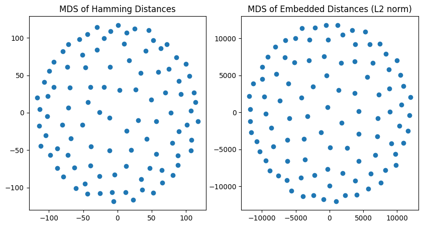

```python
# Perform multidimensional scaling and plot the old and new distances, side by side
from sklearn.manifold import MDS
import matplotlib.pyplot as plt

dpr = embedding.get_distance_matrix()

mdsEmbed = MDS(n_components=2, dissimilarity='precomputed')
mdsOld = mdsEmbed.fit_transform(d)
mdsNew = mdsEmbed.fit_transform(dpr)

fig, axs = plt.subplots(1, 2, figsize=(10, 5))
axs[0].scatter(mdsOld[:, 0], mdsOld[:, 1])
axs[0].set_title("MDS of Hamming Distances")
axs[1].scatter(mdsNew[:, 0], mdsNew[:, 1])
axs[1].set_title("MDS of Embedded Distances (L2 norm)")
plt.show()
```